# Which databases

Thomas Delcey

09/02/2022

## Presentation of main databases available

It exists a variety of large-scale bibliometric databases like Web of Science, Dimensions, Econlit, Proquest, Scopus, JSTOR. The main pros of such databases is that they are professionally managed by librarians. It results that the data are cleanner, the companies offers online library for easily exploring and exporting large-scale data. However, such database has not been built for historians, and especially historians of economics. Hence, for most of these databases, data become much poorer as we go back into the XX<sup>th</sup> century.

## Performance for older periods

For instance, for exploration purpose, you might be interested to know the number of articles mentioning a particular notion or concept, at a given period. Such result may diverge greatly from the database chosen. As an illustration, I plot below the result of a search for “rational expectations” between 1955 and 1971.

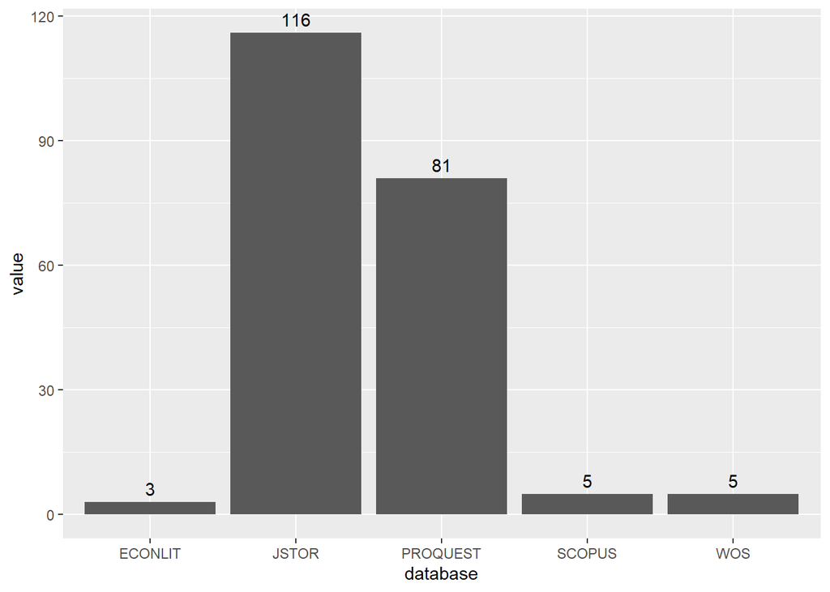

JSTOR and Proquest are by far the more comprehensive databases for period pre-1990. WOS, Scopus and Econlit performed poorly for older periods, resulting in a high number of false negative. Note, however, that it does not imply that such databases are useless. We will discuss in a next post the pros and cons of each database.

## The case of google scholar

Let’s include now google scholar in our research of ‘rational expectations’

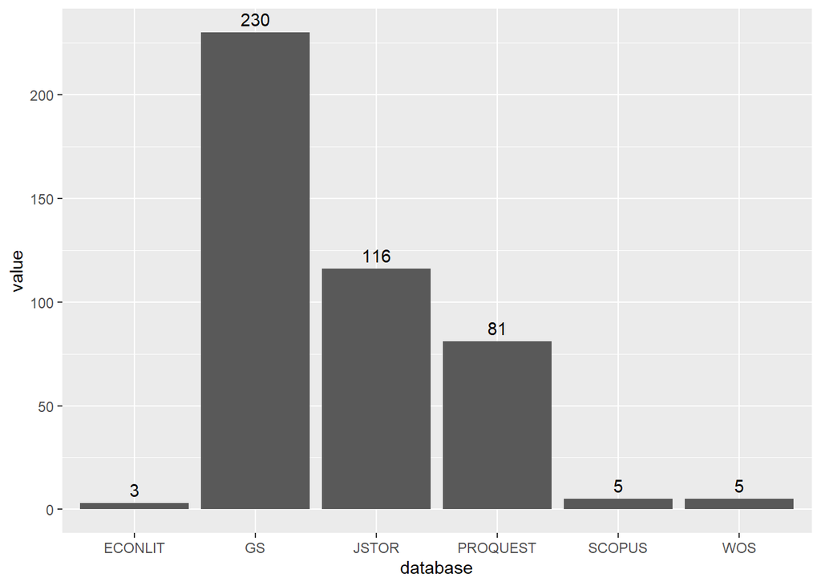

Google scholar is able to find a greater number of documents. It seems to perform far better than any database, including Proquest and Scopus. To understand why, we must understand what exactly google scholar does.

**What is google scholar ?**

Although google scholar is primarily designed for detecting published academic papers, it generally performs better to detect unusual academic documents than others database, such as preprints, books, speech, reports. Google scholar’s ability to extract metadata information may be powerful tools for historians of economics to retrieve documents that have fallen into oblivion. It is generally a fast tool that overlaps a large part of the other databases.

No matter powerful the tool is, it has also serious limitations. An unsupervised automated extraction on the web of this scale is doomed to make many mistakes. The quality of parsers extraction is obviously constrained by the quality of metadata it extracts. If html tags or first-pages from pdf are badly written, google scholar will not identify, or will badly identify, an academic documents. Symmetrically, google scholar includes also a high percentage of false positive, namely documents found by the inquiry that *are not* real documents, or documents mentioning your keyword research. Specifically, errors include, duplicated documents, non academic documents, and multiple various errors of indexing. Here is a subset of duplicates metadata from the research “rational expectations”.

Duplicates

| Authors | Title | Year |
| --- | --- | --- |
| JF Muth | Rational Expectations and the Theory of Price Movements, 29 Econometrica 315 (1961). 23 John Harsanyi, Games with Incomplete Information Played by … | 1968 |
| JF Muth | Forecasting Models: Their Development and Implications for Decision Making. | 1966 |
| JF Muth | Rational expectations and the theory of price movements | 1961 |
| JF Muth | Rational Expectations and the Theory of Price Movements” reprinted in The new classical macroeconomics | 1961 |
| JF Muth | Rational expectations and the theory of the business cycle | 1961 |

In a nutshell, google scholar may be a powerful tool for exploring and collecting data on older periods but it is important to keep in mind that he came with a price on the quality of data. Working with google scholar implies a data cleaning burden. Together with the fact that google does not offer a data export service, google scholar became less and less useful as your work with larger data. Google scholar remains, however, a useful exploratory tool, and might be used as complementary sources for research questions that involve working with small amounts of data.